# Fitting Extreme Value Distributions & Copula Estimation

### viii) PP-Plots

```
## no dparams supplied. Estimating parameters from the data...
```

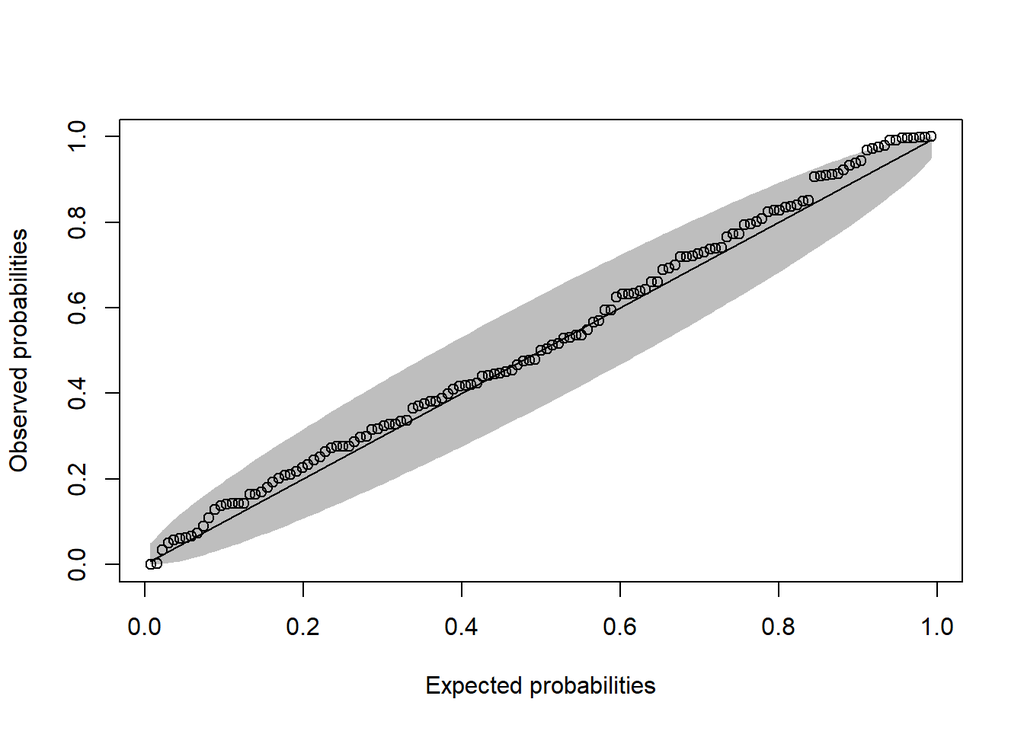

```r
pp_conf_plot(
  obs = returns$Fordex,
  distribution = pnorm
)
```

```
## no dparams supplied. Estimating parameters from the data...
```

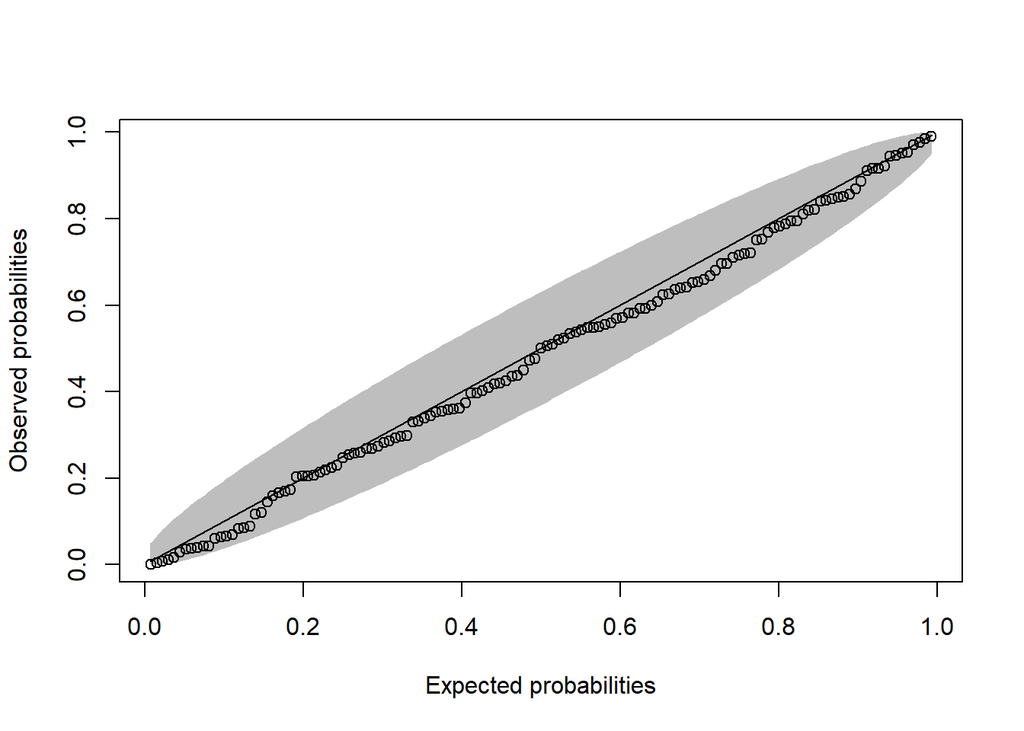

```r
pp_conf_plot(
  obs = returns$SPex,
  distribution = pnorm
)
```

The PP-Graphs plot the expected probabilities of the sample data (i.e. our respective time series) against the theoretical probabilities of a normal distribution. For the Fordex, we can observe some observations that lie outside the confidence interval (grey area) indicating that the the Fordex time series does not follow a normal distribution. In contrast, fromt he SPex PP-plot, we can assume that only very few observations fall outside the confidence interval. These are most likely the above-mentioned outliers. The PP-plots are therefore in line with the ourn interpretation of the QQ-plots, i.e. the SPex time series might be sufficiently well described by a normal distribution.

## 1.2 Fitting Extreme Distribution

The suggested extreme value distributions, namely Weibull, log-normal and Gamma, can only be fitted to positive data. Since both the SPex and Fordex time series contain negative values, we need to change the data such that we obtain solely positive values for the distribution fitting.

Therefore, we have several alternatives such as (1) adding a value to shift the data (to the right), (2) extracting only the positive values, or (3) fitting the distribution to the absolute values of the time series. For the fitting of the distribution, we use the maximum likelihood estimator.

1. Ford Excess Returns

To compare the fit of the suggested, we use combine two for loops. The first loop will iterate over the suggested approaches, while the second loop will fit the suggested distributions. Subsequently, the results will be stored and compared.

```
##
## Summary for Fordex_weibull_shift :
## Fitting of the distribution ' weibull ' by maximum likelihood
## Parameters :
##         estimate Std. Error
## shape   5.538521  0.2964041
## scale 104.824534  1.7222755
## Loglikelihood:  -581.465   AIC:  1166.93   BIC:  1172.741
## Correlation matrix:
##           shape     scale
## shape 1.0000000 0.3243206
## scale 0.3243206 1.0000000
##
##
## Plot for Fordex_weibull_shift :
```

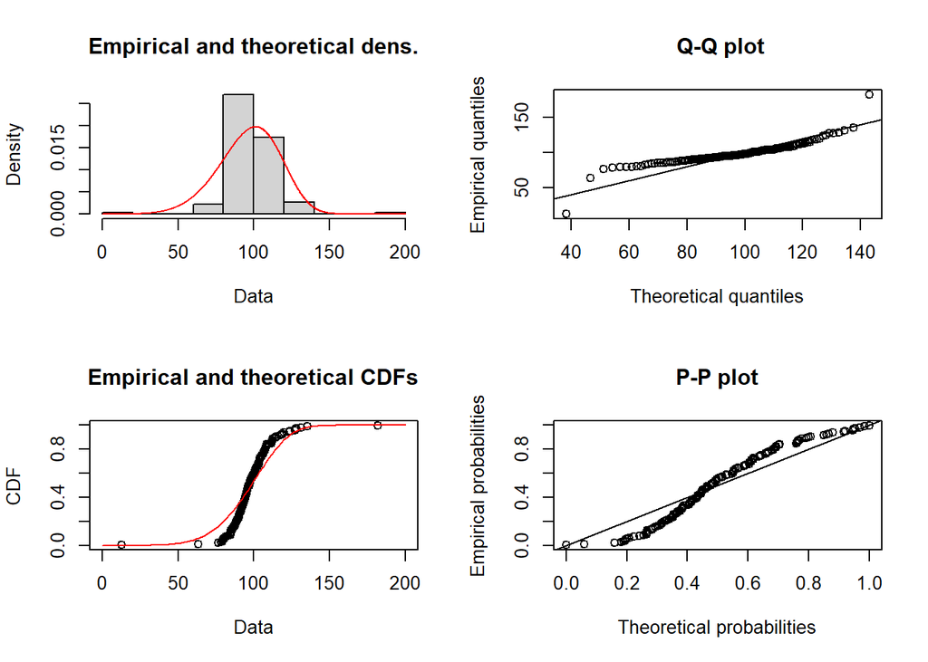

```
##
## Summary for Fordex_lnorm_shift :
## Fitting of the distribution ' lnorm ' by maximum likelihood
## Parameters :
##         estimate Std. Error
## meanlog 4.571457 0.01885970
## sdlog   0.219130 0.01333458
## Loglikelihood:  -603.7613   AIC:  1211.523   BIC:  1217.333
## Correlation matrix:
##                      meanlog                sdlog
## meanlog 1.000000000000000000 0.000000000007147666
## sdlog   0.000000000007147666 1.000000000000000000
##
##
## Plot for Fordex_lnorm_shift :
```

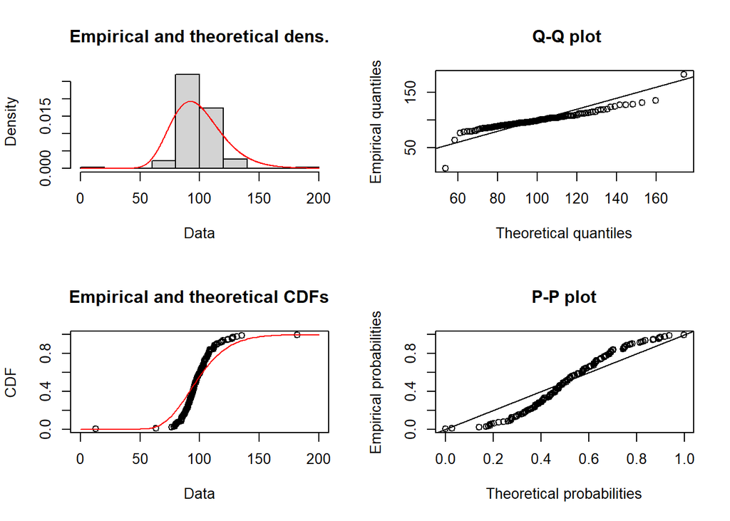

```
##
## Summary for Fordex_gamma_shift :
## Fitting of the distribution ' gamma ' by maximum likelihood
## Parameters :
##         estimate Std. Error
## shape 28.3818336 3.43287966
## rate   0.2883886 0.03519066
## Loglikelihood:  -583.6724   AIC:  1171.345   BIC:  1177.155
## Correlation matrix:
##           shape      rate
## shape 1.0000000 0.9911976
## rate  0.9911976 1.0000000
##
##
## Plot for Fordex_gamma_shift :
```

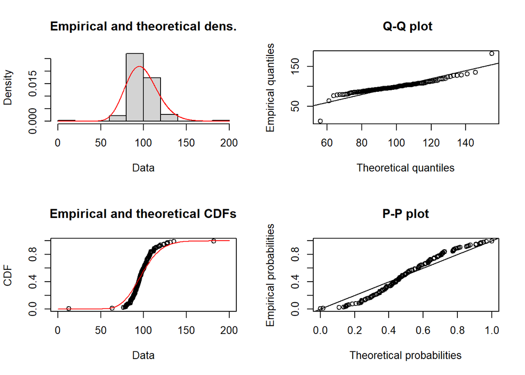

```
##
## Summary for Fordex_weibull_pos :
## Fitting of the distribution ' weibull ' by maximum likelihood
## Parameters :
##         estimate Std. Error
## shape  0.9996795 0.09988167
## scale 11.2428896 1.60364638
## Loglikelihood:  -188.1002   AIC:  380.2004   BIC:  384.2151
## Correlation matrix:
##           shape     scale
## shape 1.0000000 0.3255334
## scale 0.3255334 1.0000000
##
##
## Plot for Fordex_weibull_pos :
```

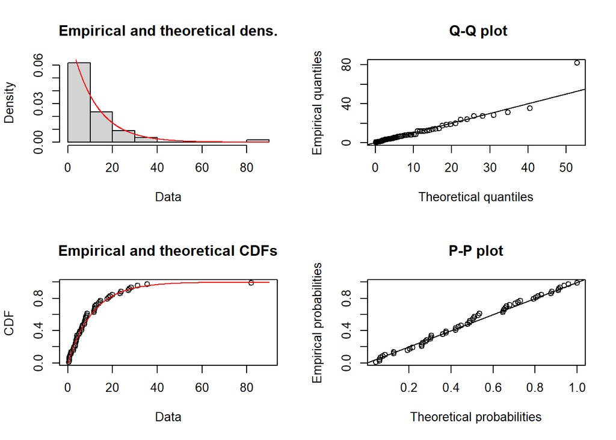

```
##
## Summary for Fordex_lnorm_pos :
## Fitting of the distribution ' lnorm ' by maximum likelihood
## Parameters :
##         estimate Std. Error
## meanlog 1.883971  0.1504326
## sdlog   1.115638  0.1063715
## Loglikelihood:  -187.6785   AIC:  379.3569   BIC:  383.3716
## Correlation matrix:
##         meanlog sdlog
## meanlog       1     0
## sdlog         0     1
##
##
## Plot for Fordex_lnorm_pos :
```

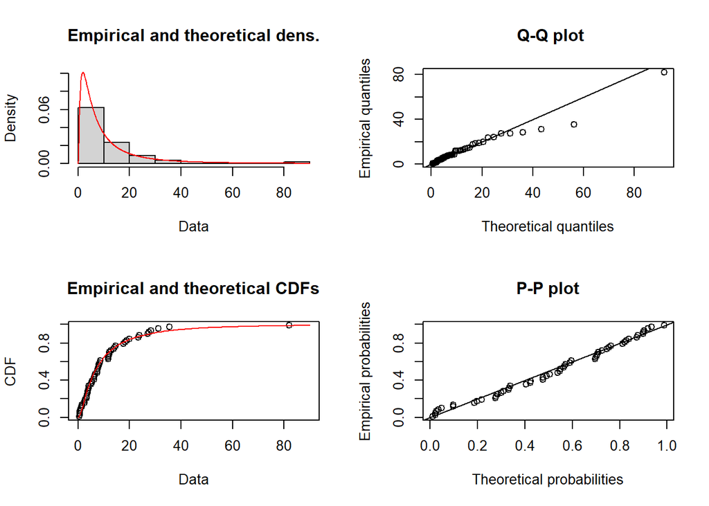

```
##
## Summary for Fordex_gamma_pos :
## Fitting of the distribution ' gamma ' by maximum likelihood
## Parameters :
##         estimate Std. Error
## shape 1.06884080 0.18049076
## rate  0.09505169 0.02027793
## Loglikelihood:  -188.0244   AIC:  380.0487   BIC:  384.0634
## Correlation matrix:
##           shape      rate
## shape 1.0000000 0.7914035
## rate  0.7914035 1.0000000
##
##
## Plot for Fordex_gamma_pos :
```

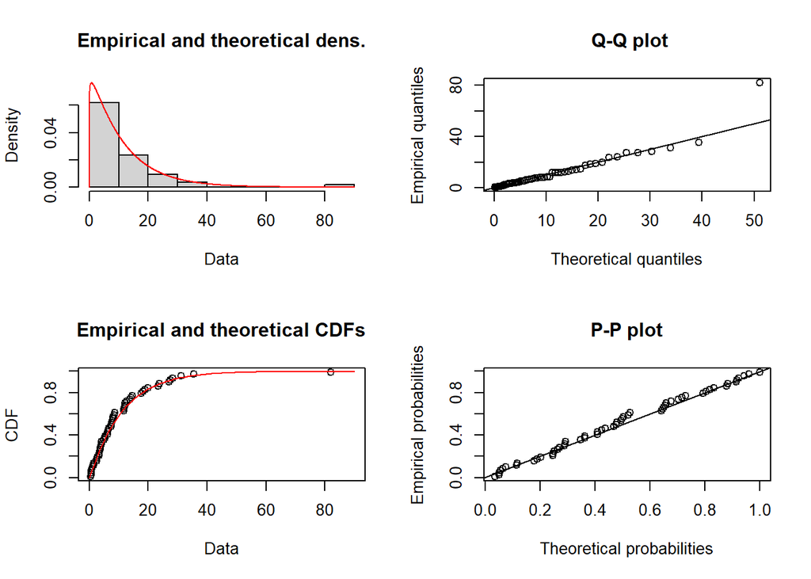

```
##
## Summary for Fordex_weibull_abs :
## Fitting of the distribution ' weibull ' by maximum likelihood
## Parameters :
##        estimate Std. Error
## shape  1.108429 0.06839136
## scale 11.217538 0.92111601
## Loglikelihood:  -454.3046   AIC:  912.6093   BIC:  918.4198
## Correlation matrix:
##           shape     scale
## shape 1.0000000 0.3246031
## scale 0.3246031 1.0000000
##
##
## Plot for Fordex_weibull_abs :
```

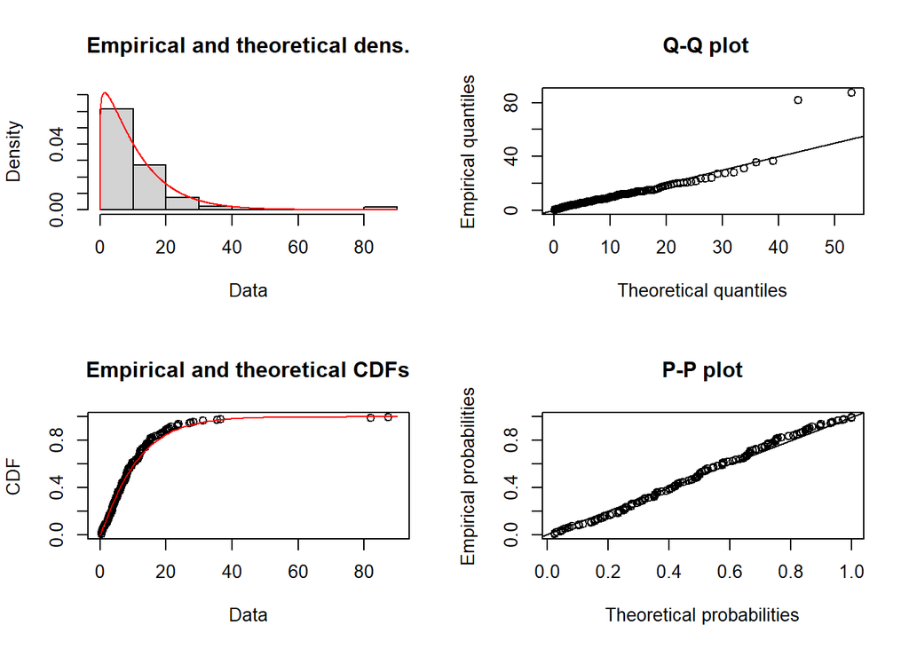

```
##
## Summary for Fordex_lnorm_abs :
## Fitting of the distribution ' lnorm ' by maximum likelihood
## Parameters :
##          estimate Std. Error
## meanlog 1.9474830 0.08549975
## sdlog   0.9934173 0.06045718
## Loglikelihood:  -453.5753   AIC:  911.1506   BIC:  916.9612
## Correlation matrix:
##         meanlog sdlog
## meanlog       1     0
## sdlog         0     1
##
##
## Plot for Fordex_lnorm_abs :
```

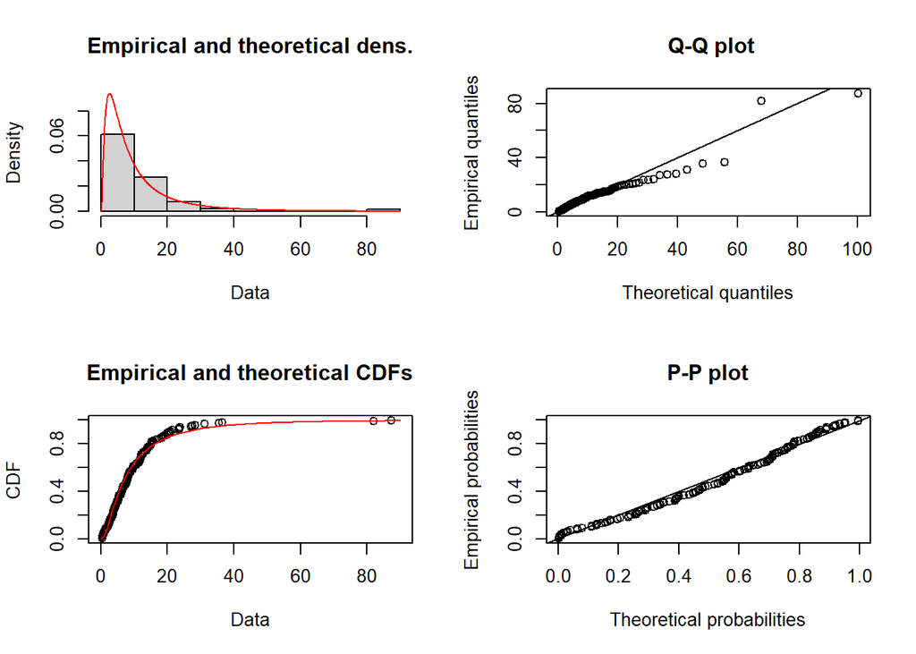

```
##
## Summary for Fordex_gamma_abs :
## Fitting of the distribution ' gamma ' by maximum likelihood
## Parameters :
##       estimate Std. Error
## shape 1.311772 0.14383372
## rate  0.122035 0.01622019
## Loglikelihood:  -452.7627   AIC:  909.5253   BIC:  915.3359
## Correlation matrix:
##           shape      rate
## shape 1.0000000 0.8248637
## rate  0.8248637 1.0000000
##
##
## Plot for Fordex_gamma_abs :
```

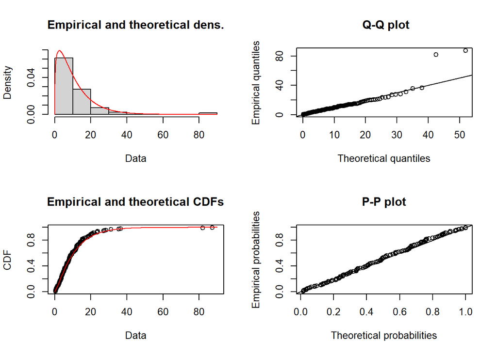

```r
distributions = c("weibull", "lnorm", "gamma")
approaches = list(returns$Fordex+100, returns$Fordex[returns$Fordex>0], abs(returns$Fordex))
fit_results <- list()

for (approach in seq_along(approaches)) {
  data <- approaches[[approach]]
  approach_name <- switch(approach, "shift", "pos", "abs")

  for (dist in distributions) {

    fit <- fitdist(data,
                 distr = dist,
                 method = "mle")

  # Store fit results
  fit_results[[paste("Fordex_", dist, "_", approach_name, sep = "")]] <- fit

  # Print summary
  cat("\nSummary for", paste("Fordex_", dist, "_", approach_name, sep = ""), ":\n")
    print(summary(fit))

    # Plot
    cat("\nPlot for", paste("Fordex_", dist, "_", approach_name, sep = ""), ":\n")
    plot(fit)
    }
}
```

Given the AIC results, we observe that for each approach a different extreme distribution (among the three candidates) describes the data best:

1. When shifting the data, the Weibull distribution describes the data best (AIC = 1166.93).
2. When using only positive values, the log-normal describes the data best (AIC = 379.3569).
3. When using the absolute values, the gamma distribution describes the data baste (AIC = 909.5253).

2. S&P500 Excess Returns